Ce Notebook a été réalisé par:

- DEMY UGO
- DE CASTELNAU HELOISE

# LIBRAIRIES

Installer

```python
#install calmap pour colab
! pip install calmap
#mettre à jour plotly pour colab
!pip install plotly==4.5.2
!pip install plotly
!pip install folium
```

```
     |████████████████████████████████| 7.1MB 4.9MB/s
  Found existing installation: plotly 4.4.1
    Uninstalling plotly-4.4.1:
      Successfully uninstalled plotly-4.4.1
```

Importer

```python
# essential libraries
import json
import random
from urllib.request import urlopen

# storing and anaysis
import numpy as np
import pandas as pd
import random
import math

# visualization
import matplotlib.pyplot as plt
import seaborn as sns
import plotly.express as px
import plotly.graph_objs as go
import plotly.figure_factory as ff
import calmap
import folium

# color pallette
cnf = '#393e46' # confirmed - grey
dth = '#ff2e63' # death - red
rec = '#21bf73' # recovered - cyan
act = '#fe9801' # active case - yellow

# converter
from pandas.plotting import register_matplotlib_converters
register_matplotlib_converters()

# hide warnings
import warnings
warnings.filterwarnings('ignore')
```

# DATASET

On charges les données des valeurs foncières 2020

```python
from google.colab import drive
drive.mount('/content/drive')
```

```python
path = '/content/drive/MyDrive/Data/valeursfoncieres-2020.txt'
dvf_2020 = pd.read_csv(path, sep = '|')
dvf_2020
```

|  | Code service CH | Reference document | 1 Articles CGI | 2 Articles CGI | 3 Articles CGI | 4 Articles CGI | 5 Articles CGI | No disposition | Date mutation | Nature mutation | Valeur fonciere | No voie | B/T/Q | Type de voie | Code voie | Voie | Code postal | Commune | Code departement | Code commune | Prefixe de section | Section | No plan | No Volume | 1er lot | Surface Carrez du 1er lot | 2eme lot | Surface Carrez du 2eme lot | 3eme lot | … |
| --- | --- | --- | --- | --- | --- | --- | --- | --- | --- | --- | --- | --- | --- | --- | --- | --- | --- | --- | --- | --- | --- | --- | --- | --- | --- | --- | --- | --- | --- | --- |
| 0 | NaN | NaN | NaN | NaN | NaN | NaN | NaN | 1 | 07/01/2020 | Vente | 8000,00 | NaN | NaN | NaN | B063 | FORTUNAT | 1250.0 | CEYZERIAT | 1 | 72 | NaN | AK | 216 | NaN | NaN | NaN | NaN | NaN | NaN | … |
| 1 | NaN | NaN | NaN | NaN | NaN | NaN | NaN | 1 | 02/01/2020 | Vente | 2175,00 | NaN | NaN | NaN | B124 | TERRES DES CINQ SAULES | 1290.0 | LAIZ | 1 | 203 | NaN | B | 4 | NaN | NaN | NaN | NaN | NaN | NaN | … |
| 2 | NaN | NaN | NaN | NaN | NaN | NaN | NaN | 1 | 02/01/2020 | Vente | 2175,00 | NaN | NaN | NaN | B006 | BOIS DU CHAMP RION | 1290.0 | LAIZ | 1 | 203 | NaN | B | 173 | NaN | NaN | NaN | NaN | NaN | NaN | … |
| 3 | NaN | NaN | NaN | NaN | NaN | NaN | NaN | 1 | 02/01/2020 | Vente | 2175,00 | NaN | NaN | NaN | B025 | EN COROBERT | 1290.0 | LAIZ | 1 | 203 | NaN | B | 477 | NaN | NaN | NaN | NaN | NaN | NaN | … |
| 4 | NaN | NaN | NaN | NaN | NaN | NaN | NaN | 1 | 02/01/2020 | Vente | 2175,00 | NaN | NaN | NaN | B124 | TERRES DES CINQ SAULES | 1290.0 | LAIZ | 1 | 203 | NaN | C | 68 | NaN | NaN | NaN | NaN | NaN | NaN | … |
| ... | ... | ... | ... | ... | ... | ... | ... | ... | ... | ... | ... | ... | ... | ... | ... | ... | ... | ... | ... | ... | ... | ... | ... | ... | ... | ... | ... | ... | ... | … |
| 2459555 | NaN | NaN | NaN | NaN | NaN | NaN | NaN | 1 | 16/12/2020 | Vente | 1937500,00 | 24.0 | NaN | RUE | 1748 | CHANOINESSE | 75004.0 | PARIS 04 | 75 | 104 | NaN | AW | 19 | NaN | NaN | NaN | NaN | NaN | NaN | … |
| 2459556 | NaN | NaN | NaN | NaN | NaN | NaN | NaN | 1 | 16/12/2020 | Vente | 1937500,00 | 24.0 | NaN | RUE | 1748 | CHANOINESSE | 75004.0 | PARIS 04 | 75 | 104 | NaN | AW | 19 | NaN | NaN | NaN | NaN | NaN | NaN | … |
| 2459557 | NaN | NaN | NaN | NaN | NaN | NaN | NaN | 1 | 16/12/2020 | Vente | 1937500,00 | 24.0 | NaN | RUE | 1748 | CHANOINESSE | 75004.0 | PARIS 04 | 75 | 104 | NaN | AW | 19 | NaN | NaN | NaN | NaN | NaN | NaN | … |
| 2459558 | NaN | NaN | NaN | NaN | NaN | NaN | NaN | 1 | 16/12/2020 | Vente | 1937500,00 | 24.0 | NaN | RUE | 1748 | CHANOINESSE | 75004.0 | PARIS 04 | 75 | 104 | NaN | AW | 19 | NaN | NaN | NaN | NaN | NaN | NaN | … |
| 2459559 | NaN | NaN | NaN | NaN | NaN | NaN | NaN | 1 | 08/10/2020 | Adjudication | 255000,00 | 39.0 | NaN | RUE | 8752 | SAINT-SAUVEUR | 75002.0 | PARIS 02 | 75 | 102 | NaN | AM | 143 | NaN | 97 | 3,20 | 98 | 17,40 | NaN | … |

2459560 rows × 43 columns

# PRETRAITEMENT

**Cleaning Data**

On regarde les colonnes ayant beaucoup de données manquantes afin de sélectionner celles qui seraient plus pertinentes à supprimer.

```python
dvf_2020_na = dvf_2020.isna().sum()
dvf_2020_na
```

```
Code service CH               2459560
Reference document            2459560
1 Articles CGI                2459560
2 Articles CGI                2459560
3 Articles CGI                2459560
4 Articles CGI                2459560
5 Articles CGI                2459560
No disposition                      0
Date mutation                       0
Nature mutation                     0
Valeur fonciere                 31752
No voie                        990345
B/T/Q                         2352374
Type de voie                  1017945
Code voie                       30948
Voie                            31123
Code postal                     30992
Commune                             0
Code departement                    0
Code commune                        0
Prefixe de section            2350554
Section                           101
No plan                             0
No Volume                     2452794
1er lot                       1702571
Surface Carrez du 1er lot     2250280
2eme lot                      2303817
Surface Carrez du 2eme lot    2408519
3eme lot                      2434251
Surface Carrez du 3eme lot    2454703
4eme lot                      2450649
Surface Carrez du 4eme lot    2458303
5eme lot                      2455417
Surface Carrez du 5eme lot    2458997
Nombre de lots                      0
Code type local               1143726
Type local                    1143726
Identifiant local             2459560
Surface reelle bati           1145290
Nombre pieces principales     1145290
Nature culture                 767675
Nature culture speciale       2352011
Surface terrain                767675
dtype: int64
```

On supprime les colonnes comportant plus de *1,700,000* valeurs NaN

```python
for index in dvf_2020_na.index:
  if dvf_2020_na[index] >= 1700000:
    del dvf_2020[index]
```

On supprime également les colonnes qui ne serviront pas à notre analyse.

```python
del dvf_2020['Code type local']
del dvf_2020['No disposition']
```

Tout d'abord on remarque que les dates de mutation sont *écrites au format francais*, ce qui pose généralement problème lors des classements par ordre chronologique. On les modifie donc pour obtenir le format MM/JJ/AAAA.

```python
date_format_eng = []
for index in dvf_2020.index:
  date = dvf_2020['Date mutation'][index].split('/')
  date_new_format = date[1]+"/" + date[0] + "/" + date[2]
  date_format_eng.append(date_new_format)
dvf_2020['Date MM/JJ/AAAA'] = date_format_eng
del dvf_2020['Date mutation']
```

```python
dvf_2020['Type de voie'].unique().shape[0]
```

```
132
```

```python
type_voie_code_Rivoli = []
code_Rivo = ["Voie", "Ensemble immobilier", "Lieu-dit", "Pseudo-voie", "Voie provisoire"]

for code in dvf_2020['Code voie']:
  code_voie = code_Rivo[2]
  if type(code) == float or type(code) == int:
    code_voie = code_Rivo[0]
  else:
    if code[0] == "A":
      code_voie = code_Rivo[1]
    if code[0] == "X":
      code_voie = code_Rivo[3]
    if code[0] == "Y" or code[0] == "Z":
      code_voie = code_Rivo[4]
    else:
      code_voie = random.choice(code_Rivo)
  type_voie_code_Rivoli.append(code_voie)

dvf_2020["Type voie - code Rivoli"] = type_voie_code_Rivoli
dvf_2020 = dvf_2020.drop(["No voie", "Type de voie", "Code voie", "Voie", "Code postal", "Nombre pieces principales", "Nombre de lots", "No plan"], axis = 1)
```

Pour remplacer les valeurs manquantes des *sections*, on regroupe les données selon les *communes* en prenant soin de mettre **les sections propres à la commune** sous forme de **liste**. On effectue ensuite un **random choice** dans cette liste de facon à compléter les 101 sections manquantes tout en respectant les proportions de sections par communes.

```python
missing_section = dvf_2020.groupby(['Commune']).agg(lambda x: list(x))
key = missing_section['Section']

for index in dvf_2020.index:
  if pd.isnull(dvf_2020['Section'][index]) == True:
    commune = dvf_2020['Commune'][index]
    new_section = random.choice(key[commune])
    dvf_2020['Section'][index] = new_section
```

Afin de compléter les missing values des valeurs foncières, on tranforme d'abord les valeurs foncières en **float** afin de pouvoir appliquer des *opérations statistiques* dessus.

```python
dvf_2020["Valeur fonciere"] = dvf_2020["Valeur fonciere"].str.replace(',','.').astype(float)
```

On cherche ensuite à regrouper les valeurs foncieres en fonction de leur *commune* et *section* respectives de facon à obtenir une **valeur foncière moyenne par section de commune**. Ensuite, on complète les *missing values* en leur attribuant la moyenne correspondante.

```python
mean_vf_commune_section = pd.DataFrame(dvf_2020.groupby(['Commune','Section']).agg({'Valeur fonciere': 'mean'}))

for index in dvf_2020.index:
  if math.isnan(dvf_2020['Valeur fonciere'][index]) == True:
    new_vf = round(mean_vf_commune_section['Valeur fonciere'][dvf_2020['Commune'][index]][dvf_2020['Section'][index]], 2)
    dvf_2020['Valeur fonciere'][index] = new_vf
```

```python
mean_vf_commune = pd.DataFrame(dvf_2020.groupby(['Commune']).agg({'Valeur fonciere': 'mean'}))

for index in dvf_2020.index:
  if math.isnan(dvf_2020['Valeur fonciere'][index]) == True:
    new_vf = round(mean_vf_commune['Valeur fonciere'][dvf_2020['Commune'][index]], 2)
    dvf_2020['Valeur fonciere'][index] = new_vf
```

Cependant, certaines communes ont **aucune valeur foncière inscrite** pour les biens renseignés. On fait donc la *moyennes des prix par région* pour les approximer.

```python
mean_vf_departement = pd.DataFrame(dvf_2020.groupby(['Code departement']).agg({'Valeur fonciere': 'mean'}))

for index in dvf_2020.index:
  if math.isnan(dvf_2020['Valeur fonciere'][index]) == True:
    new_vf = round(mean_vf_departement['Valeur fonciere'][dvf_2020['Code departement'][index]], 2)
    dvf_2020['Valeur fonciere'][index] = new_vf
```

Le libellé *Nature culture* désigne le type du terrain concerné. Ce peut être par exemple un bois *B*, un paturage *PA*, un sol *S* ou encore un terrain d'agrément *AG*. Il parait donc logique de procéder de la même facon que pour la complétion des missing values de *Section*, c'est-à-dire en attribuant **au hasard une valeur parmi la liste** des Nature culture déjà inscrites pour une section en particulier. Toujours dans un effort de conservation des proportions !

```python
dvf_2020['Nature culture'].value_counts()
```

```
S     829111
T     241955
P     127873
J      98241
AB     83904
BT     67375
AG     61910
L      58246
VI     26013
BR     24135
VE     17642
BS     11736
PA     11109
B       7811
E       7774
BP      6489
BF      3435
PP      2011
PC      1438
PH      1337
BM       839
CH       647
CA       420
LB       203
PE       113
TP        82
BO        36
Name: Nature culture, dtype: int64
```

On remarque ci-dessus que le type de terrain très largement **majoritaire** est sol **S**. Par conséquent, dans le cas d'une commune pour laquelle *aucune valeur Nature culture* n'a été renseignée, on attribuera 'S' à toutes les valeurs de cette section.

```python
missing_NC = dvf_2020.groupby(['Commune','Section']).agg(lambda x: list(x))
key_NC = missing_NC['Nature culture']

missing_NC_Commune = dvf_2020.groupby(['Commune']).agg(lambda x: list(x))
key_NC_Commune = missing_NC_Commune['Nature culture']
```

```python
for index in dvf_2020.index:
  if pd.isnull(dvf_2020['Nature culture'][index]) == True:

    commune = dvf_2020['Commune'][index]
    section = dvf_2020['Section'][index]

    if all(pd.isnull(key_NC[commune][section])) == True and all(pd.isnull(key_NC_Commune[commune])) == True:
      new_NC = 'S'

    elif all(pd.isnull(key_NC[commune][section])) == True and all(pd.isnull(key_NC_Commune[commune])) == False:
      new_NC = random.choice(key_NC_Commune[commune])
      while pd.isnull(new_NC):
        new_NC = random.choice(key_NC_Commune[commune])

    else:
      new_NC = random.choice(key_NC[commune][section])
      while pd.isnull(new_NC):
        new_NC = random.choice(key_NC[commune][section])

    dvf_2020['Nature culture'][index] = new_NC
```

```python
dvf_2020_na = dvf_2020.isna().sum()
dvf_2020_na
```

```
Date mutation                    0
Nature mutation                  0
Valeur fonciere                  0
Commune                          0
Code departement                 0
Code commune                     0
Section                          0
Type local                 1143726
Surface reelle bati        1145290
Nature culture                   0
Surface terrain             767675
Type voie - code Rivoli          0
dtype: int64
```

La *Surface terrain* semble être fortement corrélée à l'attribut *Nature Culture*. En effet, il y a précisement le même nombre de missing values pour ces 2 categories. On choisit donc ci-dessous de compléter les valeurs par **la moyenne des sections / communes groupées par Nature culture**.

```python
mean_ST = pd.DataFrame(dvf_2020.groupby(['Commune','Section','Nature culture']).agg({'Surface terrain': 'mean'}))
mean_ST_C = pd.DataFrame(dvf_2020.groupby(['Commune','Nature culture']).agg({'Surface terrain': 'mean'}))
mean_ST_CodeD = pd.DataFrame(dvf_2020.groupby(['Code departement','Nature culture']).agg({'Surface terrain': 'mean'}))


for index in dvf_2020.index:
  if math.isnan(dvf_2020['Surface terrain'][index]) == True:
    new_ST = round(mean_ST['Surface terrain'][dvf_2020['Commune'][index]][dvf_2020['Section'][index]][dvf_2020['Nature culture'][index]], 1)

    if math.isnan(new_ST) == True:
      new_ST = round(mean_ST_C['Surface terrain'][dvf_2020['Commune'][index]][dvf_2020['Nature culture'][index]], 1)

    if math.isnan(new_ST) == True:
      new_ST = round(mean_ST_CodeD['Surface terrain'][dvf_2020['Code departement'][index]][dvf_2020['Nature culture'][index]], 1)

    dvf_2020['Surface terrain'][index] = new_ST
```

On remarque que dans de nombreux cas de ventes simultanées de plusieurs maisons / appartements avec leurs dépendances, la valeur foncière et la surface terrain correspondent à *la somme de toutes les opérations* même si ces dernières sont *enregistrées séparement* dans le dataset. Pour palier à ce problème, on ne choisit de sélectionner que **la première de toute les transactions**, qui concerne en général le bien principal acquis.

```python
sorted_date_vf = dvf_2020.sort_values(by = ['Date MM/JJ/AAAA','Valeur fonciere'], ascending = False)
new_dvf = []
for index in range(1,len(sorted_date_vf)):
  transac_prec = sorted_date_vf.iloc[index-1]
  if ((sorted_date_vf.iloc[index]['Valeur fonciere'] != transac_prec['Valeur fonciere']) or (sorted_date_vf.iloc[index]['Commune'] != transac_prec['Commune']) or (sorted_date_vf.iloc[index]['Date MM/JJ/AAAA'] != transac_prec['Date MM/JJ/AAAA'])):
    new_dvf.append(sorted_date_vf.iloc[index])
dvf_2020 = pd.DataFrame(new_dvf)
```

On retire les départements d'Outre-Mer et on modifie les codes départements de la Corse pour pouvoir les traiter comme le reste des codes départements qui sont des *float* et non des *str*. De plus, certaines valeurs paraissent complètement aberrantes et faussent les visualisations en minimisant les autres. Par exemple, une vingtaine de ventes ont eu lieu le 23/12 à un prix de **~165,5 millions** que l'on décidera de supprimer.

```python
for index in dvf_2020.index:
  if dvf_2020['Code departement'][index] == '2A':
    dvf_2020['Code departement'][index] = 2.1
  if dvf_2020['Code departement'][index] == '2B':
    dvf_2020['Code departement'][index] = 2.2

  codeD = float(dvf_2020['Code departement'][index])
  print(codeD)
  if codeD >= 971 and codeD <= 989:
    dvf_2020 = dvf_2020.drop(index)
```

```python
dvf_2020 = dvf_2020.loc[(dvf_2020['Date MM/JJ/AAAA']!='12/23/2020') & (dvf_2020['Code departement']!=95) & (dvf_2020['Valeur fonciere']!=165450240)].reset_index()
del dvf_2020['index']
```

Enfin, on enregistre les données propres et completées dans un nouveau fichier .csv pour éviter d'avoir à réexécuter toutes les cellules de pré-traitement à chaque lancement.

```python
dvf_2020
```

|  | Nature mutation | Valeur fonciere | Commune | Code departement | Code commune | Section | Type local | Surface reelle bati | Nature culture | Surface terrain | Type voie - code Rivoli | Date MM/JJ/AAAA |
| --- | --- | --- | --- | --- | --- | --- | --- | --- | --- | --- | --- | --- |
| 0 | Vente terrain à bâtir | 1.493280e+08 | MERIGNAC | 33.0 | 281 | ES | NaN | NaN | P | 16838.0 | Voie | 12/31/2020 |
| 1 | Vente | 1.660000e+07 | PARIS 08 | 75.0 | 108 | BF | Appartement | 100.0 | S | 767.0 | Pseudo-voie | 12/31/2020 |
| 2 | Vente | 1.572406e+07 | LA TESTE-DE-BUCH | 33.0 | 529 | FP | Local industriel. commercial ou assimilé | 5800.0 | S | 716.8 | Pseudo-voie | 12/31/2020 |
| 3 | Vente | 1.132500e+07 | LA SEYNE SUR MER | 83.0 | 126 | AK | Local industriel. commercial ou assimilé | 110.0 | S | 6000.0 | Ensemble immobilier | 12/31/2020 |
| 4 | Vente | 8.020000e+06 | ROCHETAILLEE-SUR-SAONE | 69.0 | 168 | AD | NaN | NaN | S | 5.0 | Voie | 12/31/2020 |
| ... | ... | ... | ... | ... | ... | ... | ... | ... | ... | ... | ... | ... |
| 1045379 | Vente | 1.950000e+05 | MARSEILLE 7EME | 13.0 | 207 | E | Dépendance | 0.0 | S | 564.5 | Lieu-dit | 01/01/2020 |
| 1045380 | Vente | 1.351151e+05 | ROSIERES-AUX-SALINES | 54.0 | 462 | AB | Local industriel. commercial ou assimilé | 2349.0 | S | 403.0 | Pseudo-voie | 01/01/2020 |
| 1045381 | Vente | 1.000000e+05 | STE GEMMES SUR LOIRE | 49.0 | 278 | AM | Maison | 75.0 | S | 122.0 | Voie provisoire | 01/01/2020 |
| 1045382 | Vente | 8.750000e+04 | SAINT-POL-DE-LEON | 29.0 | 259 | AM | Dépendance | 0.0 | S | 163.5 | Ensemble immobilier | 01/01/2020 |
| 1045383 | Vente | 2.055200e+03 | BESSE | 38.0 | 40 | C | NaN | NaN | L | 10276.0 | Ensemble immobilier | 01/01/2020 |

1045384 rows × 12 columns

```python
dvf_2020.to_csv('/content/drive/MyDrive/Data/clean_dvf_data_vfchange.csv', index=False)
```

# DONNEES DE L'ANNEE 2020

Dans cette partie nous allons étudier les données sur l'année 2020. On commence par charger le dataset modifié après prétraitement des données.

```python
path = '/content/drive/MyDrive/Data/clean_dvf_data_vfchange.csv'
clean_dvf_2020 = pd.read_csv(path, sep = ',')
```

```python
clean_dvf_2020['Valeur fonciere'].mean()
```

```
230634.02043684537
```

```python
dvf_2020_na = clean_dvf_2020.isna().sum()
dvf_2020_na
```

```
Nature mutation                 0
Valeur fonciere                 0
Commune                         0
Code departement                0
Code commune                    0
Section                         0
Type local                 344321
Surface reelle bati        344911
Nature culture                  0
Surface terrain                 0
Type voie - code Rivoli         0
Date MM/JJ/AAAA                 0
dtype: int64
```

```python
paris = clean_dvf_2020.loc[clean_dvf_2020['Code departement'] == 75]
```

1. Valeur fonciere moyenne par date

Avec ce graphique nous essayons de répondre à la question suivante : Existe-t-il une saisonnalité du marché immobilier ? Nous pouvons observer que les valeurs sont peu espacées par rapport à la moyenne d'avril à août, et bien plus dispersées en hiver. Ce qui nous ferait penser que le pire moment pour investir serait au mois de juin et le meilleur moment lorsque l'offre augmente, en hiver.

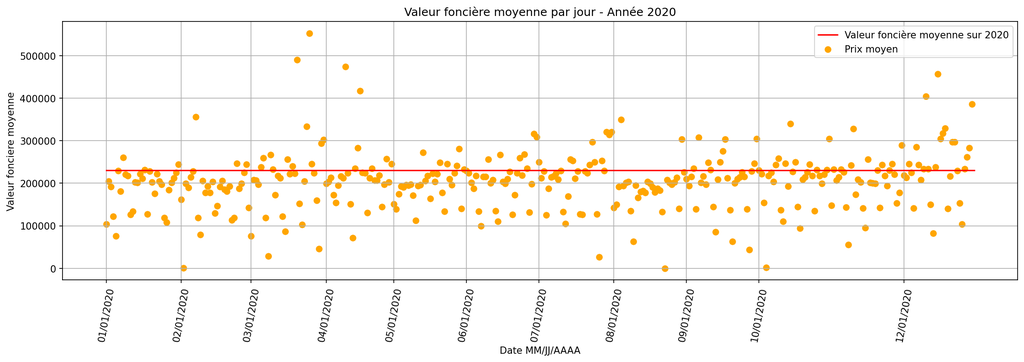

```python
plt.rcParams['figure.figsize'] = [18, 5]
plt.rcParams['figure.dpi'] = 150

df = clean_dvf_2020.groupby(['Date MM/JJ/AAAA']).mean().sort_values('Date MM/JJ/AAAA')
x = df.index
y = df['Valeur fonciere']

plt.grid(True)
plt.scatter(x, y, c = 'orange', label='Prix moyen')
plt.plot(['01/01/2020', '11/01/2020'], [230634, 230634], color = 'red', linestyle = 'solid', label='Valeur foncière moyenne sur 2020')
plt.title('Valeur foncière moyenne par jour - Année 2020')
plt.xticks(ticks = ['01/01/2020','02/01/2020','03/01/2020','04/01/2020','05/01/2020','06/01/2020','07/01/2020','08/01/2020','09/01/2020','10/01/2020','12/01/2020'], rotation=80)
plt.xlabel("Date MM/JJ/AAAA")
plt.ylabel("Valeur fonciere moyenne")
plt.legend()
plt.show()
```

1. Rapport entre les appartements et maisons vendues par département

Ce graphique nous permet d'observer le ratio appartements/maisons au sein de chaque département. La région parisienne est évidemment celle qui possède un taux infime de maisons par rapport à son nombre d'appartements. Mais d'autres départements tels que le 06 (Alpes-Maritimes) et le 13 (Bouches-du-Rhône) la précède. Il est intéressant de comparer ces départements au sein desquels se trouvent de grandes villes avec le département du Nord (59), qui malgré la présence d'une ville étudiante : Lille possède un ratio bien plus élevé de maisons.

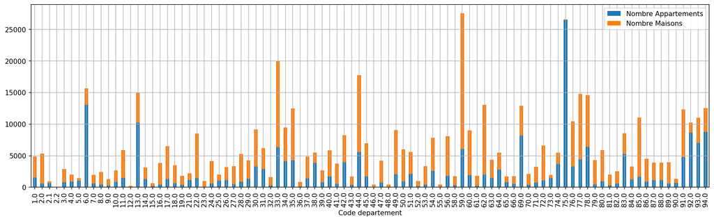

```python
maison_appart = clean_dvf_2020.loc[(clean_dvf_2020['Type local'] == 'Appartement') | (clean_dvf_2020['Type local'] == 'Maison')]
df = pd.DataFrame(maison_appart.groupby(['Type local', 'Code departement']).size())
code_departement = pd.DataFrame(maison_appart.groupby(['Code departement']).size()).index

nombre_appart = pd.DataFrame(df[0]['Appartement']).values.tolist()
nombre_maison = pd.DataFrame(df[0]['Maison']).values.tolist()

new_df_appart = pd.DataFrame(nombre_appart, columns = ["Nombre Appartements"], index = code_departement)
new_df_maison = pd.DataFrame(nombre_maison, columns = ["Nombre Maisons"], index = code_departement)
new_df = pd.concat([new_df_appart,new_df_maison], axis = 1)
new_df.plot.bar(grid = True, stacked=True)
```

1. Taux de natures des mutations en France sur 2020

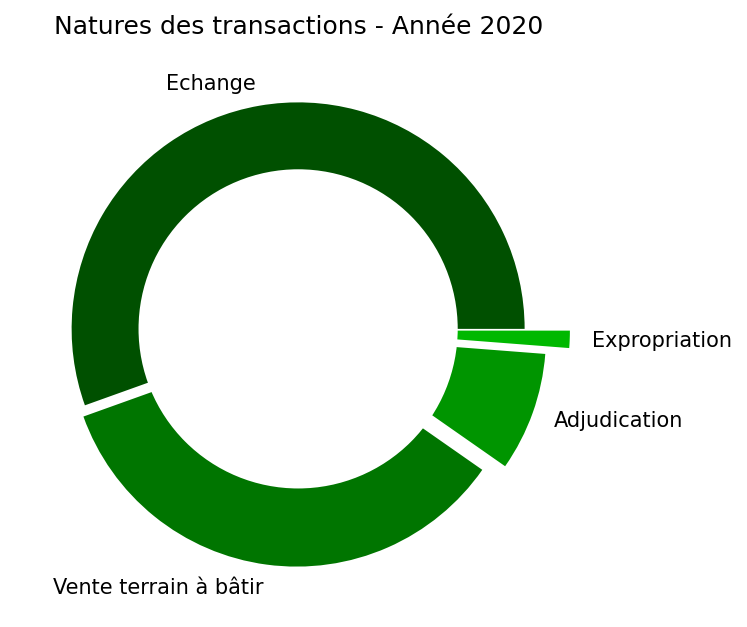

```python
nature_mutation = clean_dvf_2020['Nature mutation'].value_counts().tail(4)
x = nature_mutation.index.tolist()
y = nature_mutation.tolist()

explode = [0, 0.05, 0.1, 0.2]
mycolors = ["#005000", "#007500", "#009500", "#00b800"]
plt.pie(y, labels = x, explode = explode, colors = mycolors)
plt.title("Natures des transactions - Année 2020")

# Add a circle at the center to transform it in a donut chart
my_circle=plt.Circle( (0,0), 0.7, color='white')
p=plt.gcf()
p.gca().add_artist(my_circle)

plt.show()
```

1. Evolution du nombre de biens vendus pendant l'année 2020

On peut observer le nombre de biens vendus par jour pendant l'année 2020. On remarque tout de suite un creux qui correspond aux dates du premier confinement en France (17/03-11/05), qui a entraîné une chute de la vente immobilière qui, d'après le graphique a fini par se stabiliser en décembre.

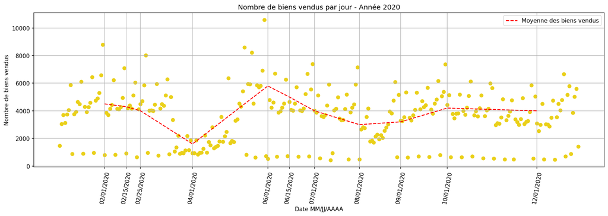

```python
#Quels sont les mois où l'immobilier se porte le mieux ?
df = clean_dvf_2020['Date MM/JJ/AAAA'].value_counts().sort_values(ascending = False).head(290)
df = df.sort_index()
x = df.index.tolist()
y = df.tolist()

plt.grid(True)
plt.scatter(x, y, c = '#ead019')

mean_x = ['02/01/2020','02/15/2020','02/25/2020','04/01/2020','06/01/2020','06/15/2020','07/01/2020','08/01/2020', '09/01/2020','10/01/2020','12/01/2020']
mean_y = [4500, 4300, 4000, 1600, 5800, 5000, 4000, 3000, 3200, 4200, 4000]

plt.plot(mean_x, mean_y, color = 'red', linestyle = 'dashed', label='Moyenne des biens vendus')
plt.title('Nombre de biens vendus par jour - Année 2020')
plt.xticks(ticks = mean_x, rotation=80)
plt.xlabel("Date MM/JJ/AAAA")
plt.ylabel('Nombre de biens vendus')
plt.legend()
plt.show()
```

1. Les 10 communes les plus chères

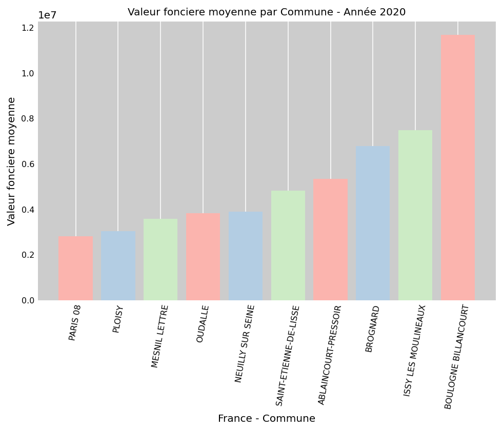

```python
expensive_communes = clean_dvf_2020.groupby(['Commune']).mean().sort_values(['Valeur fonciere']).tail(10)
x = expensive_communes.index
y = expensive_communes['Valeur fonciere']

fig, ax = plt.subplots(figsize=(8, 5), dpi=144)
colors = plt.cm.Pastel1(range(3))
ax.bar(x, y, color=colors)
plt.title('Valeur fonciere moyenne par Commune - Année 2020', fontsize = 10)
plt.xticks(rotation = 80)
plt.xlabel("France - Commune", fontsize = 10)
plt.ylabel("Valeur fonciere moyenne", fontsize = 10)
nice_axes(ax)
```

1. Quel est le prix moyen d'un bien immobilier dans le 93 ?

On se demande ici quel est le prix moyen de l'immobilier en Seine-Saint-Denis et le prix moyen de chaque département. Ainsi, dans le 93 la valeur foncière moyenne se situe aux alentours des 400 000 euros.

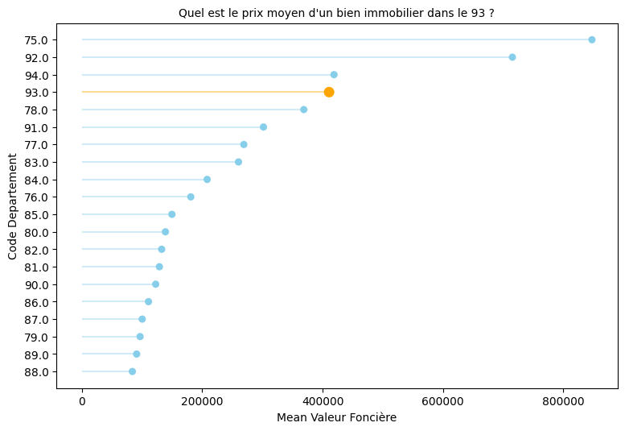

```python
plt.rcParams['figure.figsize'] = [9, 6]
plt.rcParams['figure.dpi'] = 100

# Create a dataframe
df = clean_dvf_2020.groupby(['Code departement']).mean().tail(20)

# Reorder it based on values:
ordered_df = df.sort_values(['Valeur fonciere'])
my_range=range(1,len(df.index)+1)

# Create a color if the group is "B"
my_color=np.where(ordered_df.index == 93.0, 'orange', 'skyblue')
my_size=np.where(ordered_df.index == 93.0, 70, 30)

# The horizontal plot is made using the hline() function
plt.hlines(y=my_range, xmin=0, xmax=ordered_df['Valeur fonciere'].tolist(), color=my_color, alpha=0.4)
plt.scatter(ordered_df['Valeur fonciere'].tolist(), my_range, color=my_color, s=my_size, alpha=1)

# Add title and axis names
plt.yticks(my_range, ordered_df.index)
plt.title("Quel est le prix moyen d'un bien immobilier dans le 93 ?", fontsize = 10)
plt.xlabel('Mean Valeur Foncière')
plt.ylabel('Code Departement')

# show the graph
plt.show()
```

1. Nombre de biens vendus par departement

On représente ici une carte avec une échelle du nombre de biens vendus par département. On remarque que les départements du centre semblent moins populaires que ceux de la côte atlantique et du Grand Est, ce dernier ayant réalisé de très bonnes ventes durant l'année 2020.

```python
!pip install geopandas
import geopandas as gpd
```

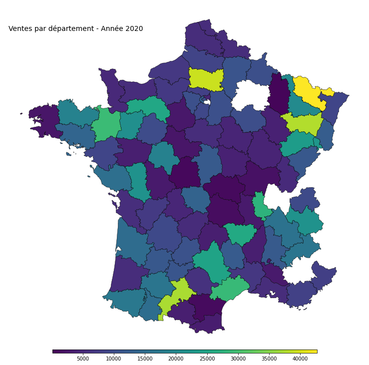

```python
# Load file
url = "https://france-geojson.gregoiredavid.fr/repo/departements.geojson"
geoData = gpd.read_file(url)

# Merge the clean_dvf_2020 dataset with the geospatial information
df = pd.DataFrame(clean_dvf_2020.groupby(['Code departement']).size())
geoData = geoData.loc[geoData['code'] != '2A']
geoData = geoData.loc[geoData['code'] != '2B']
geoData['Code departement'] = geoData['code'].astype(float)
geoData = geoData.drop(['code'], axis = 1)
geoData.set_index('Code departement').sort_index()
df = df.drop([2.1, 2.2], axis = 0)
geoData = geoData.drop([20.0, 57.0, 67.0, 68.0], axis = 0)
geoData["Nombre ventes"] = df[0].tolist()

fig, ax = plt.subplots(1, figsize=(13, 13))

# map departement with the right color:
geoData.plot(
    ax=ax,
    column="Nombre ventes",
    cmap="viridis",
    norm=plt.Normalize(vmin=102, vmax=42715),
    edgecolor='black',
    linewidth=.5
);

# Remove useless axis
ax.axis('off');

# Add title
ax.annotate('Ventes par département - Année 2020', xy=(10,650),  xycoords='axes pixels', horizontalalignment='left', verticalalignment='top', fontsize=14, color='black')

# Add a color bar
sm = plt.cm.ScalarMappable(cmap='viridis', norm=plt.Normalize(vmin=102, vmax=42715))
fig.colorbar(sm, orientation="horizontal", aspect=75, fraction=0.01, pad=0 );
```

1. Valeur foncière moyenne en fonction du type de voie (code Rivoli)

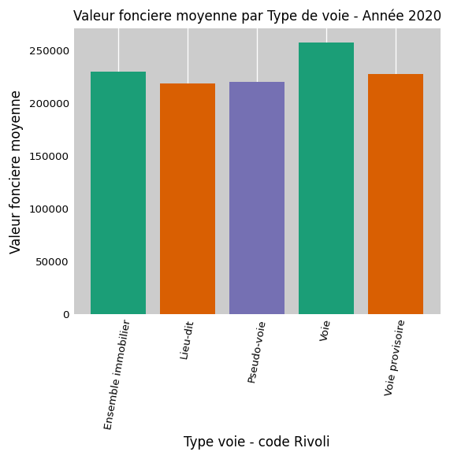

```python
type_voie = clean_dvf_2020.groupby(['Type voie - code Rivoli']).mean().sort_values(['Type voie - code Rivoli'])
x = type_voie.index
y = type_voie['Valeur fonciere'].tolist()

fig, ax = plt.subplots(figsize=(5, 4), dpi=120)
colors = plt.cm.Dark2(range(3))
ax.bar(x, y, color=colors)
plt.title('Valeur fonciere moyenne par Type de voie - Année 2020', fontsize = 10)
plt.xticks(rotation = 80)
plt.xlabel("Type voie - code Rivoli", fontsize = 10)
plt.ylabel("Valeur fonciere moyenne", fontsize = 10)
nice_axes(ax)
```

1. Evolution du nombre de biens vendus sur les 20 communes les plus "actives"

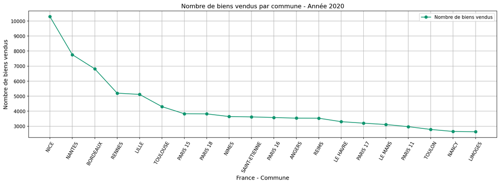

```python
#Quel commune vend le plus
plt.rcParams['figure.figsize'] = [18, 5]
plt.rcParams['figure.dpi'] = 150

vendus_commune = clean_dvf_2020.groupby(['Commune']).size().sort_values(ascending = False).head(20)
x = vendus_commune.index
y = vendus_commune.tolist()

plt.plot(x, y, color='#119670', marker='o', label = 'Nombre de biens vendus')
plt.title('Nombre de biens vendus par commune - Année 2020', fontsize = 13)
plt.xticks(rotation=60)
plt.xlabel("France - Commune", fontsize = 12)
plt.ylabel("Nombre de biens vendus", fontsize = 12)
plt.legend(loc = 'upper right')
plt.grid(True)
plt.show()
```

1. Relation entre Valeur foncière et Surface terrain en fonction des départements - France 2020

On étudie ici la corrélation entre la valeur fincière et la surface du terrain par département.

```python
commune_mean = clean_dvf_2020.groupby(['Code departement']).mean().sort_values('Valeur fonciere', ascending = False).head(25)
departements = commune_mean.index
vf = commune_mean['Valeur fonciere'].tolist()
st = commune_mean['Surface terrain'].tolist()

df = pd.DataFrame({
'Departements': departements,
'Valeur foncière *1000$': [i /1000 for i in vf],
'Surface terrain': st,
})
df
```

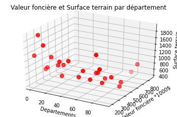

```python
from mpl_toolkits.mplot3d import Axes3D

fig = plt.figure()
ax = fig.add_subplot(111, projection='3d')
ax.scatter(df['Departements'], df['Valeur foncière *1000$'], df['Surface terrain'], c='red', s=60)
ax.set_xlabel('Departements')
ax.set_ylabel('Valeur foncière *1000$')
ax.set_zlabel('Surface terrain')
ax.set_title("Valeur foncière et Surface terrain par département")
plt.show()
```

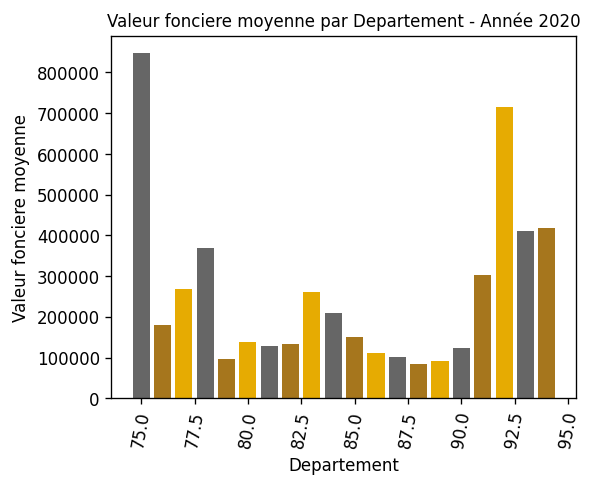

```python
df = clean_dvf_2020.groupby(['Code departement']).mean().tail(20)
x = df.index
y = df['Valeur fonciere'].tolist()

fig, ax = plt.subplots(figsize=(5, 4), dpi=120)
colors = plt.cm.Dark2_r(range(3))
ax.bar(x, y, color=colors)
plt.title('Valeur fonciere moyenne par Departement - Année 2020', fontsize = 10)
plt.xticks(rotation = 80)
plt.xlabel("Departement", fontsize = 10)
plt.ylabel("Valeur fonciere moyenne", fontsize = 10)
```

1. Les 10 Nature culture les plus fréquents derrière les sols (S)

Nous avions déjà déterminé précédemment que les sols prédominaient la nature des terrains. Ici on peut observer que les terrains les plus commercialisées sont les terres (T), les terrains à bâtir (AB) et les jardins (J). Ceux qui sont moins populaires sont les vergers (VE), les vignes (VI) et les futaies résineuses (BR).

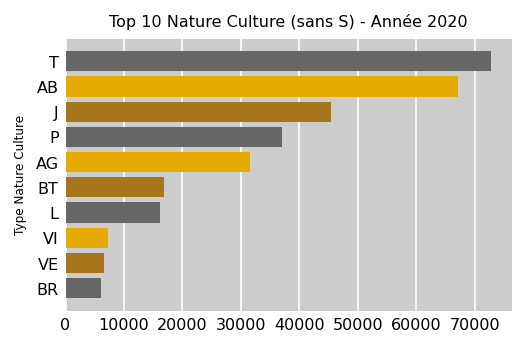

```python
nature_culture = clean_dvf_2020['Nature culture'].value_counts().sort_values()[-11:-1]

fig, ax = plt.subplots(figsize=(4, 2.5), dpi=144)
colors = plt.cm.Dark2_r(range(3))
y = nature_culture.index.tolist()
width = nature_culture.tolist()
ax.barh(y = y, width = width, color=colors)

def nice_axes(ax):
    ax.set_facecolor('.8')
    ax.tick_params(labelsize=8, length=0)
    ax.grid(True, axis='x', color='white')
    ax.set_axisbelow(True)
    [spine.set_visible(False) for spine in ax.spines.values()]

plt.title('Top 10 Nature Culture (sans S) - Année 2020', fontsize = 8)
plt.ylabel("Type Nature Culture", fontsize = 6)
nice_axes(ax)
```

1. Paris - Valeur fonciere moyenne par arrondissement

Nous pouvons observer que les arrondissements du centre de paris font partie des plus chers. C'est le 8ème arrondissement qui a enregistré dès les prix moyens les plus élevés à près de 3 millions d'euros.

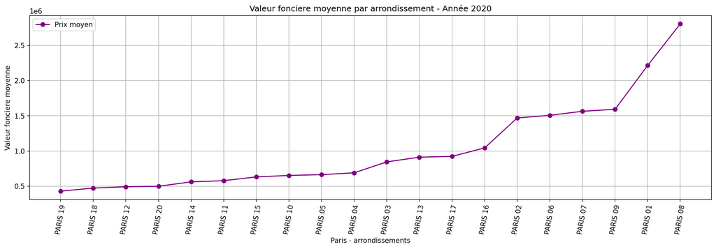

```python
arrondissement_paris = paris.groupby(['Commune']).mean().sort_values(['Valeur fonciere'])
x = arrondissement_paris.index
y = arrondissement_paris['Valeur fonciere']

plt.plot(x, y, color='purple', marker='o', label='Prix moyen')
plt.title('Valeur fonciere moyenne par arrondissement - Année 2020')
plt.xticks(rotation=80)
plt.xlabel("Paris - arrondissements")
plt.ylabel("Valeur fonciere moyenne")
plt.legend(loc = 'upper left')
plt.grid(True)
plt.show()
```

1. Paris - Nombre de biens vendus par arrondissement

```python
import folium
import json
geo = json.load(open("/content/drive/MyDrive/Data/arrondissements.geojson"))
paris_arr_circle = folium.Map(location = [48.856578, 2.351828], zoom_start = 12)
vente_arrondissement = pd.DataFrame(paris['Commune'].value_counts().sort_index())['Commune'].tolist()

index = 0
for arr in geo["features"]:
    prop = arr["properties"]
    folium.CircleMarker(prop["geom_x_y"],
                        popup = prop["l_ar"],
                        radius = vente_arrondissement[index] / 100).add_to(paris_arr_circle,)
    index +=1

paris_arr_circle
```

Make this Notebook Trusted to load map: File -> Trust Notebook

[interactive chart not shown]

1. Boxplot de la surface terrain des arrondissements parisiens

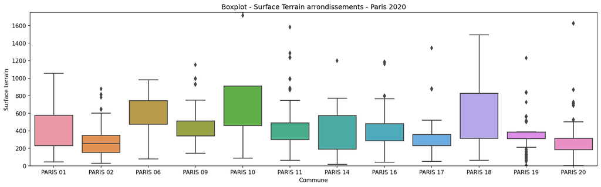

```python
#Quel arrondissement comptabilise les plus grosses ventes en termes de surface
plt.rcParams['figure.figsize'] = [18, 5]
plt.rcParams['figure.dpi'] = 150

arrondissement_paris = paris.sort_values(['Commune']).reset_index()
df = arrondissement_paris[['Commune','Surface terrain']]

# On enleve les arrondissements qui faussent les boxplots
df = df.loc[(df['Surface terrain'] != 0) & (df['Commune'] != 'PARIS 03') & (df['Commune'] != 'PARIS 04') & (df['Commune'] != 'PARIS 05') & (df['Commune'] != 'PARIS 07') & (df['Commune'] != 'PARIS 08') & (df['Commune'] != 'PARIS 12') & (df['Commune'] != 'PARIS 13') & (df['Commune'] != 'PARIS 15')]

# Boxplot
ax = sns.boxplot(x = 'Commune', y = 'Surface terrain', data = df)
ax.set_ylim([0,1750])

# add title
plt.title("Boxplot - Surface Terrain arrondissements - Paris 2020")
plt.show()
```

1. Paris - Comparaison Spyderplot 3 premiers arrondissements

On peut observer ici un emboitement des 3 premiers arrondissements de Paris dans leur analyse de leur valeur foncière, surface terrain et surface réelle bâties. Le premier arrondissement est le plus cher avec une plus grande surface globale. Suivit du 2z puis du 3e selon leurs valeurs foncières mais les deux ayant une surface globalement similaire. Il semblerait "moins rentable" d'investir dans le 2e.

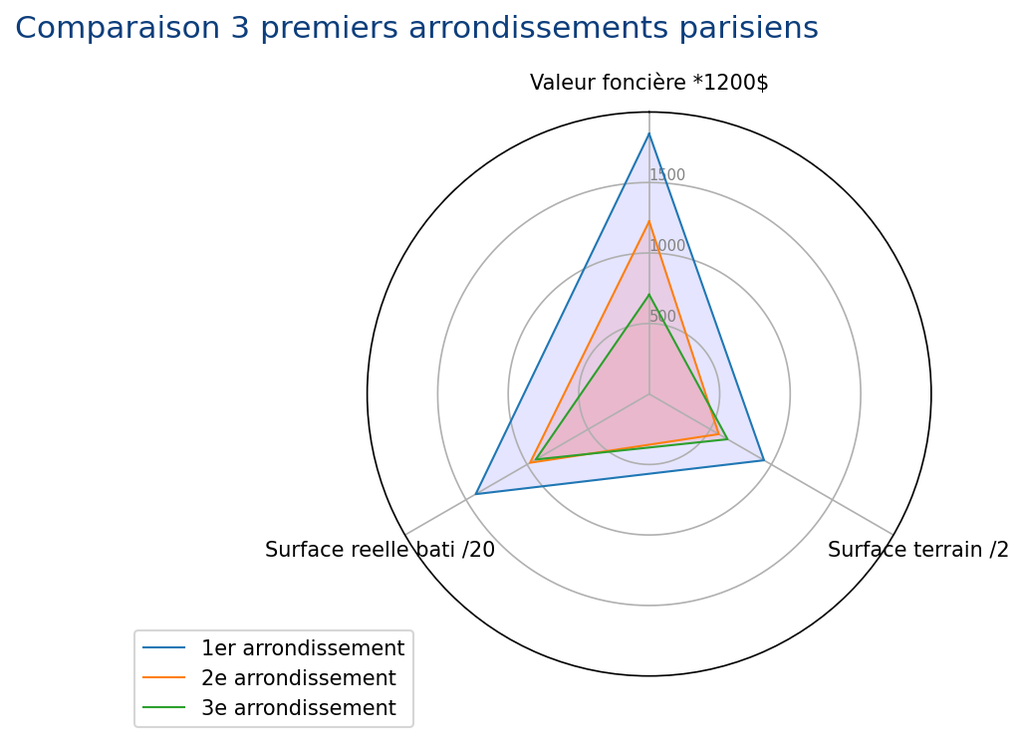

```python
import math

spyderplot = paris.groupby(['Commune']).mean().sort_values('Commune')
arrondissement = spyderplot.index
vf = spyderplot['Valeur fonciere'].tolist()
st = spyderplot['Surface terrain'].tolist()
srb = spyderplot['Surface reelle bati'].tolist()
df = pd.DataFrame({
'Arrondissement': arrondissement,
'Valeur foncière *1200$': [i /1200 for i in vf],
'Surface terrain /2': [i *2 for i in st],
'Surface reelle bati /20': [i *20 for i in srb],
})

# number of variables
categories=list(df)[1:]
N = len(categories)

# What will be the angle of each axis in the plot?
angles = [n / float(N) * 2 * math.pi for n in range(N)]
angles += angles[:1]

# Initialise the spider plot
ax = plt.subplot(111, polar=True)

# If you want the first axis to be on top:
ax.set_theta_offset(math.pi / 2)
ax.set_theta_direction(-1)

# Draw one axe per variable + add labels
plt.xticks(angles[:-1], categories)

# Draw ylabels
ax.set_rlabel_position(0)
plt.yticks([500,1000,1500], ["500","1000","1500"], color="grey", size=7)
plt.ylim(0,2000)

# Arr1
values=df.loc[0].drop('Arrondissement').values.flatten().tolist()
values += values[:1]
ax.plot(angles, values, linewidth=1, linestyle='solid', label="1er arrondissement")
ax.fill(angles, values, 'b', alpha=0.1)

# Arr2
values=df.loc[1].drop('Arrondissement').values.flatten().tolist()
values += values[:1]
ax.plot(angles, values, linewidth=1, linestyle='solid', label="2e arrondissement")
ax.fill(angles, values, 'r', alpha=0.1)

# Arr3
values=df.loc[2].drop('Arrondissement').values.flatten().tolist()
values += values[:1]
ax.plot(angles, values, linewidth=1, linestyle='solid', label="3e arrondissement")
ax.fill(angles, values, 'r', alpha=0.1)

# Add legend
plt.legend(loc='upper right', bbox_to_anchor=(0.1, 0.1))

# Add title
ax.annotate('Comparaison 3 premiers arrondissements parisiens', xy=(50,650),  xycoords='axes pixels', horizontalalignment='center', verticalalignment='center', fontsize=15, color='#0d3e7c')

# Show the graph
plt.show()
```

1. Paris - Relation entre Valeur foncière et Surface terrain en fonction des arrondissements

À l'exception du 9e arrondissement, on remarque que la valeur foncière moyenne qui en diminuant, la surface moyenne par arrondissement semble augmenter notamment pour les quartiers de la périphérie. Le centre de Paris, lui semble se composer majoritairement de petits terrains à prix relativement élevé par rapport à la surface.

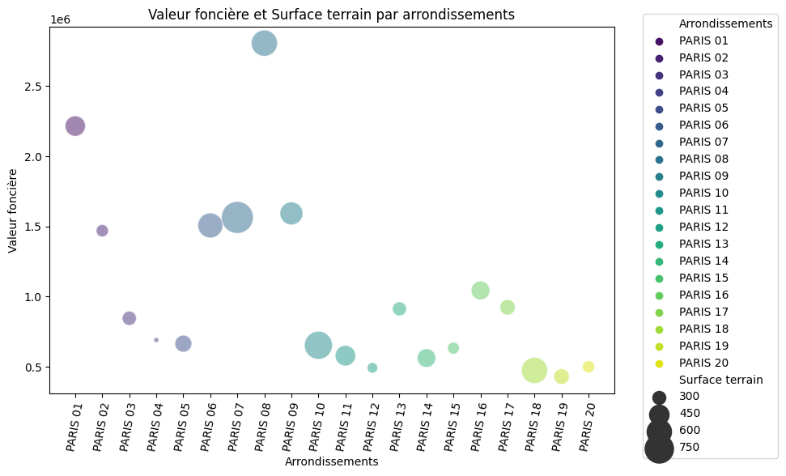

```python
arrondissement_sfvf = paris.groupby(['Commune']).mean().sort_values('Commune')
arrondissement = arrondissement_sfvf.index
vf = arrondissement_sfvf['Valeur fonciere'].tolist()
st = arrondissement_sfvf['Surface terrain'].tolist()

df = pd.DataFrame({
'Arrondissements': arrondissement,
'Valeur foncière': vf,
'Surface terrain': st,
})

sns.scatterplot(data=df, x="Arrondissements", y="Valeur foncière", size="Surface terrain", hue = "Arrondissements", palette="viridis", edgecolors="black", alpha=0.5, sizes=(20, 800))
# Add titles (main and on axis)
plt.xticks(rotation = 80)
plt.title("Valeur foncière et Surface terrain par arrondissements")
plt.legend(loc='upper right', bbox_to_anchor=(1.3, 1.05))
plt.show()
```

1. Valeur fonciere moyenne par arrondissement - Lyon Année 2020

```python
lyon = clean_dvf_2020.loc[(clean_dvf_2020['Commune'].str.contains("LYON")) & (clean_dvf_2020['Commune'].str.contains("EME"))]
lyon
```

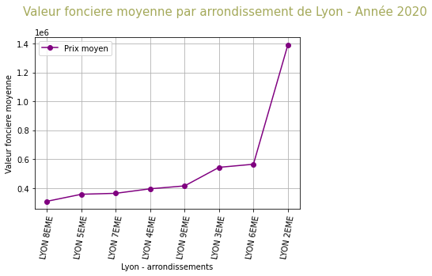

```python
arrondissement_lyon = lyon.groupby(['Commune']).mean().sort_values(['Valeur fonciere'])
x = arrondissement_lyon.index
y = arrondissement_lyon['Valeur fonciere']

plt.plot(x, y, color='purple', marker='o', label='Prix moyen')
plt.annotate('Valeur fonciere moyenne par arrondissement de Lyon - Année 2020', xy=(240,250),  xycoords='axes pixels', horizontalalignment='center', verticalalignment='center', fontsize=15, color='#a4a95a')
plt.xticks(rotation=80)
plt.xlabel("Lyon - arrondissements")
plt.ylabel("Valeur fonciere moyenne")
plt.legend(loc = 'upper left')
plt.grid(True)
plt.show()
```

1. Nombre de biens vendus par arrondissement - Lyon Année 2020

On peut analyser ici que tous comme les biens à Paris, ceux à Lyon se vendent le mieux en été. On observe des pics à 70 ventes par jour vers Mai-Juin.

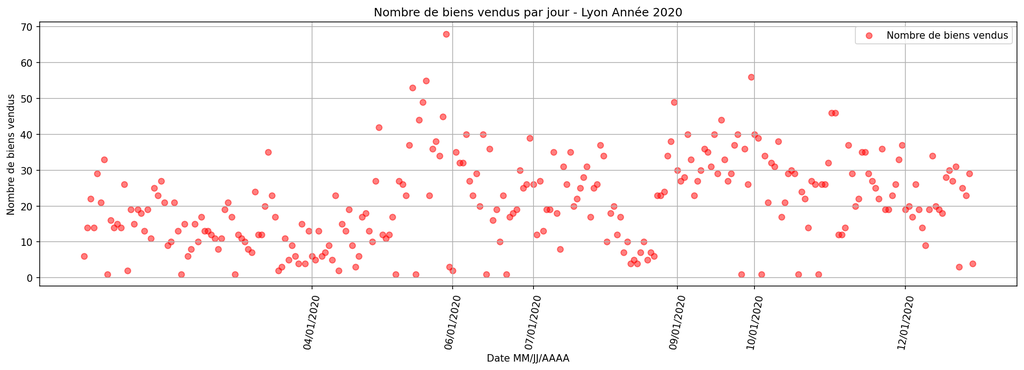

```python
plt.rcParams['figure.figsize'] = [18, 5]
plt.rcParams['figure.dpi'] = 150

df = clean_dvf_2020['Date MM/JJ/AAAA'].value_counts().sort_values(ascending = False).head(290)
df = df.sort_index()
x = df.index.tolist()
y = df.tolist()

df = lyon['Date MM/JJ/AAAA'].value_counts().sort_values(ascending = False)
df = df.sort_index()
x = df.index.tolist()
y = df.tolist()

plt.grid(True)
plt.scatter(x, y, c = 'red', alpha = 0.5, label='Nombre de biens vendus')
plt.title('Nombre de biens vendus par jour - Lyon Année 2020')
plt.xticks(ticks = ['04/01/2020','06/01/2020','07/01/2020','09/01/2020','10/01/2020','12/01/2020'], rotation=80)
plt.xlabel("Date MM/JJ/AAAA")
plt.ylabel("Nombre de biens vendus")
plt.legend()
plt.show()
```

1. Nombre de biens vendus par Arrondissement - Lyon 2020

On recherche ici quels sont les arrondissements les plus populaires à Lyon. Ce sont les quartiers du Vieux Lyon (5ème) et le 9ème, tous deux à formant la partie ouest de la ville qui attire le plus. La presqu'île (2ème) et le 6ème quant à aux font partie du bas du classement.

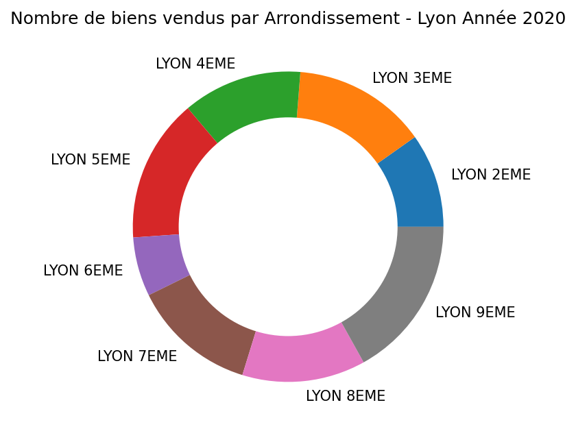

```python
arrondissement_lyon = lyon.groupby(['Commune']).size()
x = arrondissement_lyon.index.tolist()
y = arrondissement_lyon.tolist()

plt.pie(y, labels = x)
plt.title("Nombre de biens vendus par Arrondissement - Lyon Année 2020")

# Add a circle at the center to transform it in a donut chart
my_circle=plt.Circle( (0,0), 0.7, color='white')
p=plt.gcf()
p.gca().add_artist(my_circle)

plt.show()
```

# COMPARATIF ENTRE 2019 ET 2020

Traitement des données - **Ne pas exécuter cette partie**

```python
path = '/content/drive/MyDrive/Data/valeursfoncieres-2019.txt'
dvf_2019 = pd.read_csv(path, sep = '|')
dvf_2019
```

```python
dvf_2019_na = dvf_2019.isna().sum()
dvf_2019_na
```

```python
for index in dvf_2019_na.index:
  if dvf_2019_na[index] >= 1700000:
    del dvf_2019[index]
```

```python
del dvf_2019['Code type local']
del dvf_2019['No disposition']
```

```python
date_format_eng = []
for index in dvf_2019.index:
  date = dvf_2019['Date mutation'][index].split('/')
  date_new_format = date[1]+"/" + date[0] + "/" + date[2]
  date_format_eng.append(date_new_format)
dvf_2019['Date MM/JJ/AAAA'] = date_format_eng
del dvf_2019['Date mutation']
```

```python
type_voie_code_Rivoli = []
code_Rivo = ["Voie", "Ensemble immobilier", "Lieu-dit", "Pseudo-voie", "Voie provisoire"]

for code in dvf_2019['Code voie']:
  code_voie = code_Rivo[2]
  if type(code) == float or type(code) == int:
    code_voie = code_Rivo[0]
  else:
    if code[0] == "A":
      code_voie = code_Rivo[1]
    if code[0] == "X":
      code_voie = code_Rivo[3]
    if code[0] == "Y" or code[0] == "Z":
      code_voie = code_Rivo[4]
    else:
      code_voie = random.choice(code_Rivo)
  type_voie_code_Rivoli.append(code_voie)

dvf_2019["Type voie - code Rivoli"] = type_voie_code_Rivoli
dvf_2019 = dvf_2019.drop(["No voie", "Type de voie", "Code voie", "Voie", "Code postal", "Nombre pieces principales", "Nombre de lots", "No plan"], axis = 1)
```

```python
missing_section = dvf_2019.groupby(['Commune']).agg(lambda x: list(x))
key = missing_section['Section']

for index in dvf_2019.index:
  if pd.isnull(dvf_2019['Section'][index]) == True:
    commune = dvf_2019['Commune'][index]
    new_section = random.choice(key[commune])
    dvf_2019['Section'][index] = new_section
```

```python
dvf_2019["Valeur fonciere"] = dvf_2019["Valeur fonciere"].str.replace(',','.').astype(float)
```

```python
mean_vf_commune_section = pd.DataFrame(dvf_2019.groupby(['Commune','Section']).agg({'Valeur fonciere': 'mean'}))

for index in dvf_2019.index:
  if math.isnan(dvf_2019['Valeur fonciere'][index]) == True:
    new_vf = round(mean_vf_commune_section['Valeur fonciere'][dvf_2019['Commune'][index]][dvf_2019['Section'][index]], 2)
    dvf_2019['Valeur fonciere'][index] = new_vf
```

```python
mean_vf_commune = pd.DataFrame(dvf_2019.groupby(['Commune']).agg({'Valeur fonciere': 'mean'}))

for index in dvf_2019.index:
  if math.isnan(dvf_2019['Valeur fonciere'][index]) == True:
    new_vf = round(mean_vf_commune['Valeur fonciere'][dvf_2019['Commune'][index]], 2)
    dvf_2019['Valeur fonciere'][index] = new_vf
```

```python
mean_vf_commune = pd.DataFrame(dvf_2019.groupby(['Commune']).agg({'Valeur fonciere': 'mean'}))

for index in dvf_2019.index:
  if math.isnan(dvf_2019['Valeur fonciere'][index]) == True:
    new_vf = round(mean_vf_commune['Valeur fonciere'][dvf_2019['Commune'][index]], 2)
    dvf_2019['Valeur fonciere'][index] = new_vf
```

```python
sorted_date_vf = dvf_2019.sort_values(by = ['Date MM/JJ/AAAA','Valeur fonciere'], ascending = False)
new_dvf = []
for index in range(1,len(sorted_date_vf)):
  transac_prec = sorted_date_vf.iloc[index-1]
  if ((sorted_date_vf.iloc[index]['Valeur fonciere'] != transac_prec['Valeur fonciere']) or (sorted_date_vf.iloc[index]['Commune'] != transac_prec['Commune']) or (sorted_date_vf.iloc[index]['Date MM/JJ/AAAA'] != transac_prec['Date MM/JJ/AAAA'])):
    new_dvf.append(sorted_date_vf.iloc[index])
dvf_2019 = pd.DataFrame(new_dvf)
```

```python
for index in dvf_2019.index:
  if dvf_2019['Code departement'][index] == '2A':
    dvf_2019['Code departement'][index] = 2.1
  if dvf_2019['Code departement'][index] == '2B':
    dvf_2019['Code departement'][index] = 2.2

  codeD = float(dvf_2019['Code departement'][index])
  if codeD >= 971 and codeD <= 989:
    dvf_2019 = dvf_2019.drop(index)
```

```python
dvf_2019.to_csv('/content/drive/MyDrive/Data/clean_dvf_data2019_vfchange.csv', index=False)
```

A **executer a partir d'ici** pour éviter le traitement des données à nouveau

```python
path = '/content/drive/MyDrive/Data/clean_dvf_data2019_vfchange.csv'
clean_dvf_2019 = pd.read_csv(path, sep = ',')
```

```python
date_format = []
for index in clean_dvf_2019.index:
  date = clean_dvf_2019['Date MM/JJ/AAAA'][index].split('/')
  date_new_format = date[0]+"/" + date[1]
  date_format.append(date_new_format)
clean_dvf_2019['Date MM/JJ'] = date_format
```

```python
date_format = []
for index in clean_dvf_2020.index:
  date = clean_dvf_2020['Date MM/JJ/AAAA'][index].split('/')
  date_new_format = date[0]+"/" + date[1]
  date_format.append(date_new_format)
clean_dvf_2020['Date MM/JJ'] = date_format
```

```python
clean_dvf_2019 = clean_dvf_2019.loc[(clean_dvf_2019['Date MM/JJ/AAAA'] != '01/01/2019') & (clean_dvf_2019['Date MM/JJ/AAAA'] != '01/08/2019') & (clean_dvf_2019['Date MM/JJ/AAAA'] != '10/20/2019') & (clean_dvf_2019['Date MM/JJ/AAAA'] != '12/29/2019')].reset_index()
del clean_dvf_2019['index']
```

```python
dvf_2019_na = clean_dvf_2019.isna().sum()
dvf_2019_na
```

```
level_0                         0
Nature mutation                 0
Valeur fonciere                 0
Commune                         0
Code departement                0
Code commune                    0
Section                         1
Type local                 498585
Surface reelle bati        499648
Nature culture             597455
Surface terrain            597455
Date MM/JJ/AAAA                 0
Type voie - code Rivoli         0
Date MM/JJ                      0
dtype: int64
```

1. Evolution du prix sur l'annee avec la moyenne

On observe que notre hypothèse effectuée à partir des données de 2020 sur la saisonnalité de l'immobilier se confirme. Les meilleures ventes semblent bien s'effectuer au printemps-été et être moindres en hiver.

```python
df_2019 = clean_dvf_2019.groupby(['Date MM/JJ']).mean().sort_values('Date MM/JJ')
x_2019 = df_2019.index
y_2019 = df_2019['Valeur fonciere']
for index in y_2019.index:
  if y_2019[index] > 750000:
    print(index)
```

[output not shown]

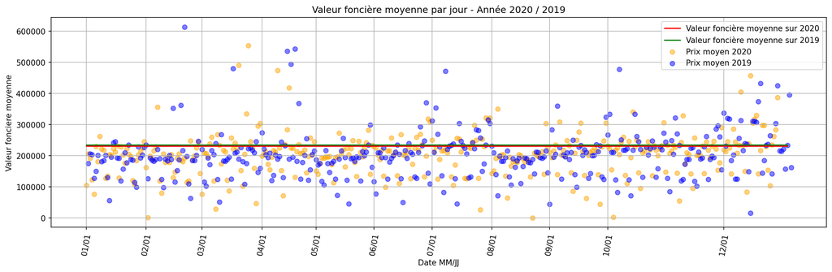

```python
plt.rcParams['figure.figsize'] = [18, 5]
plt.rcParams['figure.dpi'] = 150

df = clean_dvf_2020.groupby(['Date MM/JJ']).mean().sort_values('Date MM/JJ')
x = df.index
y = df['Valeur fonciere']

df_2019 = clean_dvf_2019.groupby(['Date MM/JJ']).mean().sort_values('Date MM/JJ')
x_2019 = df_2019.index
y_2019 = df_2019['Valeur fonciere']

plt.grid(True)
plt.scatter(x, y, c = 'orange', alpha = 0.5, label='Prix moyen 2020')
plt.scatter(x_2019, y_2019, c = 'blue', alpha = 0.5, label='Prix moyen 2019')
plt.plot(['01/01', '11/01'], [230634, 230634], color = 'red', linestyle = 'solid', label='Valeur foncière moyenne sur 2020')
plt.plot(['01/01', '11/01'], [clean_dvf_2019['Valeur fonciere'].mean(), clean_dvf_2019['Valeur fonciere'].mean()], color = 'green', linestyle = 'solid', label='Valeur foncière moyenne sur 2019')
plt.title('Valeur foncière moyenne par jour - Année 2020 / 2019')
plt.xticks(ticks = ['01/01','02/01','03/01','04/01','05/01','06/01','07/01','08/01','09/01','10/01', '12/01'], rotation=80)
plt.xlabel("Date MM/JJ")
plt.ylabel("Valeur fonciere moyenne")
plt.legend()
plt.show()
```

1. Evolution de la part de maisons / appart achetés par departement

On remarque que le ration de ventes de Maisons/appartements semble être le même chaque année.

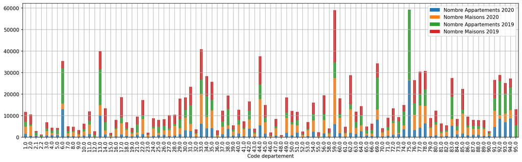

```python
# Donnees sur Appart / Maisons 2020
maison_appart = clean_dvf_2020.loc[(clean_dvf_2020['Type local'] == 'Appartement') | (clean_dvf_2020['Type local'] == 'Maison')]
df = pd.DataFrame(maison_appart.groupby(['Type local', 'Code departement']).size())
code_departement = pd.DataFrame(maison_appart.groupby(['Code departement']).size()).index

nombre_appart = pd.DataFrame(df[0]['Appartement']).values.tolist()
nombre_maison = pd.DataFrame(df[0]['Maison']).values.tolist()

new_df_appart = pd.DataFrame(nombre_appart, columns = ["Nombre Appartements 2020"], index = code_departement)
new_df_maison = pd.DataFrame(nombre_maison, columns = ["Nombre Maisons 2020"], index = code_departement)

# Donnees sur Appart / Maisons 2019
maison_appart_2019 = clean_dvf_2019.loc[(clean_dvf_2019['Type local'] == 'Appartement') | (clean_dvf_2019['Type local'] == 'Maison')]
df_2019 = pd.DataFrame(maison_appart_2019.groupby(['Type local', 'Code departement']).size())
code_departement_2019 = pd.DataFrame(maison_appart_2019.groupby(['Code departement']).size()).index

nombre_appart_2019 = pd.DataFrame(df_2019[0]['Appartement']).values.tolist()
nombre_maison_2019 = pd.DataFrame(df_2019[0]['Maison']).values.tolist()

new_df_appart_2019 = pd.DataFrame(nombre_appart_2019, columns = ["Nombre Appartements 2019"], index = code_departement_2019)
new_df_maison_2019 = pd.DataFrame(nombre_maison_2019, columns = ["Nombre Maisons 2019"], index = code_departement_2019)


new_df = pd.concat([new_df_appart, new_df_maison, new_df_appart_2019, new_df_maison_2019], axis = 1)
new_df.plot.bar(grid = True, stacked=True)
```

1. Evolution du prix par arrondissement a Paris avec surface terrain

```python
paris_2019 = clean_dvf_2019.loc[clean_dvf_2019['Code departement'] == 75]
```

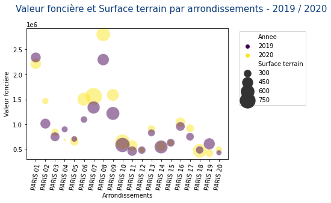

```python
arrondissement_sfvf = paris.groupby(['Commune']).mean().sort_values('Commune')
arrondissement = arrondissement_sfvf.index
vf = arrondissement_sfvf['Valeur fonciere'].tolist()
st = arrondissement_sfvf['Surface terrain'].tolist()
annee = [2020]*(len(arrondissement_sfvf.index))

df_2020 = pd.DataFrame({
'Arrondissements': arrondissement,
'Valeur foncière': vf,
'Surface terrain': st,
'Annee': annee
})

arrondissement_sfvf_2019 = paris_2019.groupby(['Commune']).mean().sort_values('Commune')
arrondissement_2019 = arrondissement_sfvf_2019.index
vf_2019 = arrondissement_sfvf_2019['Valeur fonciere'].tolist()
st_2019 = arrondissement_sfvf_2019['Surface terrain'].tolist()
annee_2019 = [2019]*(len(arrondissement_sfvf_2019.index))

df_2019 = pd.DataFrame({
'Arrondissements': arrondissement_2019,
'Valeur foncière': vf_2019,
'Surface terrain': st_2019,
'Annee': annee_2019
})

df = pd.concat([df_2020, df_2019], axis = 0)

sns.scatterplot(data=df, x="Arrondissements", y="Valeur foncière", size="Surface terrain", hue = "Annee", palette="viridis", edgecolors="black", alpha=0.5, sizes=(20, 800))

# Add titles (main and on axis)
plt.xticks(rotation = 80)
plt.annotate('Valeur foncière et Surface terrain par arrondissements - 2019 / 2020', xy=(240,250),  xycoords='axes pixels', horizontalalignment='center', verticalalignment='center', fontsize=15, color='#0d3e7c')
plt.legend(loc='upper right', bbox_to_anchor=(1.4, 1))
plt.show()
```

1. Evolution du nombre de biens vendus dans les 20 premières communes entre 2019 et 2020

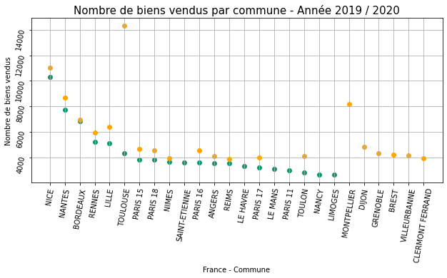

```python
vendus_commune = clean_dvf_2020.groupby(['Commune']).size().sort_values(ascending = False).head(20)
x = vendus_commune.index
y = vendus_commune.tolist()

vendus_commune_2019 = clean_dvf_2019.groupby(['Commune']).size().sort_values(ascending = False).head(20)
x_2019 = vendus_commune_2019.index
y_2019 = vendus_commune_2019.tolist()

figure = plt.figure(figsize = (10, 10))
plt.gcf().subplots_adjust(left = 0.1, bottom = 0.1,
                       right = 0.9, top = 0.9, wspace = 0, hspace = 0.5)

axes = figure.add_subplot(2.5, 1, 2)
axes.set_ylabel("Nombre de biens vendus")
axes.set_title('Nombre de biens vendus par commune - Année 2020', fontsize = 15)
axes.tick_params(labelrotation=80)
axes.scatter(x, y, color='#119670', marker='o', label = 'Nombre de biens vendus')
axes.grid(True)

axes = figure.add_subplot(2.5, 1, 2)
axes.set_xlabel("France - Commune")
axes.set_ylabel("Nombre de biens vendus")
axes.set_title('Nombre de biens vendus par commune - Année 2019 / 2020', fontsize = 15)
axes.scatter(x_2019, y_2019, color='orange', marker='o', label = 'Nombre de biens vendus')
axes.tick_params(labelrotation=80)
axes.grid(True)
```

1. Valeur foncière et Surface terrain par Arrondissement - Lyon 2020 / 2019

On remarque que comme à Paris, la valeur foncière et la surface terrain semblent corrélés. La valeur foncière moyenne diminuant, la surface moyenne par arrondissement semble augmenter.

```python
lyon_2019 = clean_dvf_2019.loc[(clean_dvf_2019['Commune'].str.contains("LYON")) & (clean_dvf_2019['Commune'].str.contains("EME"))]
```

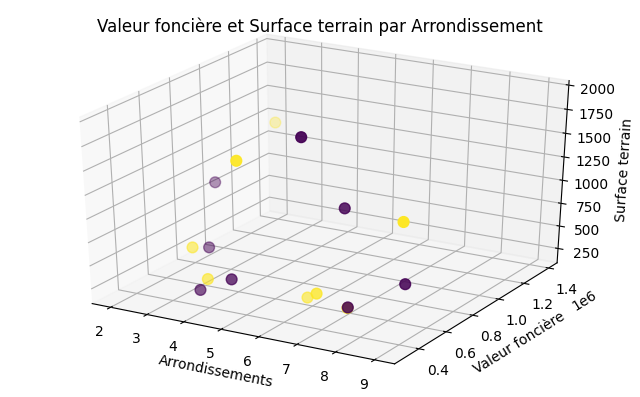

```python
plt.rcParams['figure.figsize'] = [8, 5]
plt.rcParams['figure.dpi'] = 100

arrondissement_sfvf = lyon.groupby(['Commune']).mean().sort_values('Commune')
arrondissement = arrondissement_sfvf.index
vf = arrondissement_sfvf['Valeur fonciere'].tolist()
st = arrondissement_sfvf['Surface terrain'].tolist()
annee = [2020]*(len(arrondissement_sfvf.index))

df_2020 = pd.DataFrame({
'Arrondissements': arrondissement,
'Valeur foncière': vf,
'Surface terrain': st,
'Annee': annee
})

arrondissement_sfvf_2019 = lyon_2019.groupby(['Commune']).mean().sort_values('Commune')
arrondissement_2019 = arrondissement_sfvf_2019.index
vf_2019 = arrondissement_sfvf_2019['Valeur fonciere'].tolist()
st_2019 = arrondissement_sfvf_2019['Surface terrain'].tolist()
annee_2019 = [2019]*(len(arrondissement_sfvf_2019.index))

df_2019 = pd.DataFrame({
'Arrondissements': arrondissement_2019,
'Valeur foncière': vf_2019,
'Surface terrain': st_2019,
'Annee': annee_2019
})

df = pd.concat([df_2020, df_2019], axis = 0)
df['Arrondissements'] = [2, 3, 4, 5, 6, 7, 8, 9, 2, 3, 4, 5, 6, 7, 8, 9]
fig = plt.figure()
ax = fig.add_subplot(111, projection='3d')
ax.scatter(df['Arrondissements'], df['Valeur foncière'], df['Surface terrain'], c=df['Annee'], s=60)
ax.set_xlabel('Arrondissements')
ax.set_ylabel('Valeur foncière')
ax.set_zlabel('Surface terrain')
ax.set_title("Valeur foncière et Surface terrain par Arrondissement")
plt.show()
```